# Fiscal Futures: Pension Presentation Comparison

Fiscal year: **2026**. Amounts are nominal dollars; individual tables and figures identify their units.

Both views use the same expenditure inclusion rules. The separate view moves identified pension expenditures into **Pension Expenditure**. Statewide revenue, expenditure, and fiscal-gap totals are checked for agreement for every year before exports are written.

Use the tabs beside expenditure outputs and bar graphs to compare pension presentations. Revenue, statewide totals, fund-type comparisons, and Medicaid/provider-tax analyses appear once because they do not change between pension presentations.

Non-pension spending by retirement agencies currently stays in the agency categories in both views. The review section below records the alternative treatment in the older separate-pension report; no decision on that treatment has been imposed.

### Current-year summary

Statewide totals ($ millions)

| Year | Expenditures | Revenue | Fiscal Gap |
| --- | --- | --- | --- |
| 2026 | 120177.5 | 125879.9 | 5702.31 |

**Pensions within agencies**

Expenditure categories ($ millions)

| Category_name | Dollars |
| --- | --- |
| Medicaid | 38123.90 |
| K-12 Education | 20464.50 |
| Human Services | 10557.33 |
| Local Govt Transfers | 9389.92 |
| Transportation | 6933.12 |
| University Education | 5133.97 |
| State Employee Healthcare | 3905.69 |
| State Emp. Retirement System (SERS) | 2452.34 |
| IL State Tollway | 2087.01 |
| Debt Service | 2038.57 |
| Children & Family Services | 1807.91 |
| Corrections | 1775.09 |
| Aging | 1742.03 |
| Commerce & Economic Opportunity | 1721.42 |
| Central Management | 1371.69 |
| Public Safety | 1363.53 |
| Elected Officers | 1260.28 |
| Environmental Protection Agency | 1219.86 |
| Revenue | 1039.83 |
| State Lottery | 931.67 |
| Capital Improvements | 921.08 |
| Judicial | 805.12 |
| Public Health | 680.95 |
| Family Services (net Medicaid) | 451.59 |
| Natural Resources | 414.00 |
| Other Boards & Commissions | 373.47 |
| Business & Professional Regulation | 304.67 |
| Employment Security | 283.56 |
| Legislative | 198.06 |
| Veterans' Affairs | 184.21 |
| Agriculture | 106.17 |
| IL Power Agency | 60.93 |
| GOMB | 32.21 |
| Labor | 19.41 |
| Human Rights | 19.35 |
| Early Childhood | 3.10 |

**Pensions separately**

Expenditure categories ($ millions)

| Category_name | Dollars |
| --- | --- |
| Medicaid | 38123.90 |
| K-12 Education | 13605.59 |
| Pension Expenditure | 12131.40 |
| Human Services | 10524.54 |
| Local Govt Transfers | 9389.92 |
| Transportation | 6665.31 |
| State Employee Healthcare | 3905.69 |
| University Education | 2814.24 |
| IL State Tollway | 2087.01 |
| Debt Service | 2038.57 |
| Children & Family Services | 1807.91 |
| Corrections | 1775.09 |
| Aging | 1741.50 |
| Commerce & Economic Opportunity | 1721.42 |
| Central Management | 1371.69 |
| Public Safety | 1348.43 |
| Elected Officers | 1251.48 |
| Environmental Protection Agency | 1209.75 |
| Revenue | 1039.83 |
| State Lottery | 929.09 |
| Capital Improvements | 912.94 |
| Public Health | 680.95 |
| Judicial | 652.34 |
| Family Services (net Medicaid) | 413.95 |
| Natural Resources | 401.47 |
| Other Boards & Commissions | 360.86 |
| Employment Security | 283.56 |
| Business & Professional Regulation | 256.54 |
| Legislative | 170.31 |
| Veterans' Affairs | 168.66 |
| State Emp. Retirement System (SERS) | 156.71 |
| Agriculture | 101.90 |
| IL Power Agency | 60.93 |
| GOMB | 32.21 |
| Labor | 19.41 |
| Human Rights | 19.35 |
| Early Childhood | 3.10 |

### All Funds vs General Funds

**Work in progress!**

```
# A tibble: 9 × 3
# Groups:   fy [1]
     fy fund_cat_name           Revenue
  <dbl> <chr>                     <dbl>
1  2026 Bond Financed Fund     1993478.
2  2026 Debt Service Fund   1883905358.
3  2026 Federal Trust Fund  5602267595.
4  2026 General Funds      52413032215.
5  2026 Highway Fund        8991071038.
6  2026 REVOLVING Fund          175128.
7  2026 Revolving Fund        11575920.
8  2026 Special State Fund 47823781401.
9  2026 State Trust Fund    9152046093.
```

```
# A tibble: 8 × 3
# Groups:   fy [1]
     fy fund_cat_name      Expenditures
  <dbl> <chr>                     <dbl>
1  2026 Bond Financed Fund  2859109858.
2  2026 Federal Trust Fund  6405597980.
3  2026 General Funds      45956535437.
4  2026 Highway Fund        5629329392.
5  2026 REVOLVING Fund         3676420.
6  2026 Revolving Fund       918963055.
7  2026 Special State Fund 43340512412.
8  2026 State Trust Fund    3635334137.
```

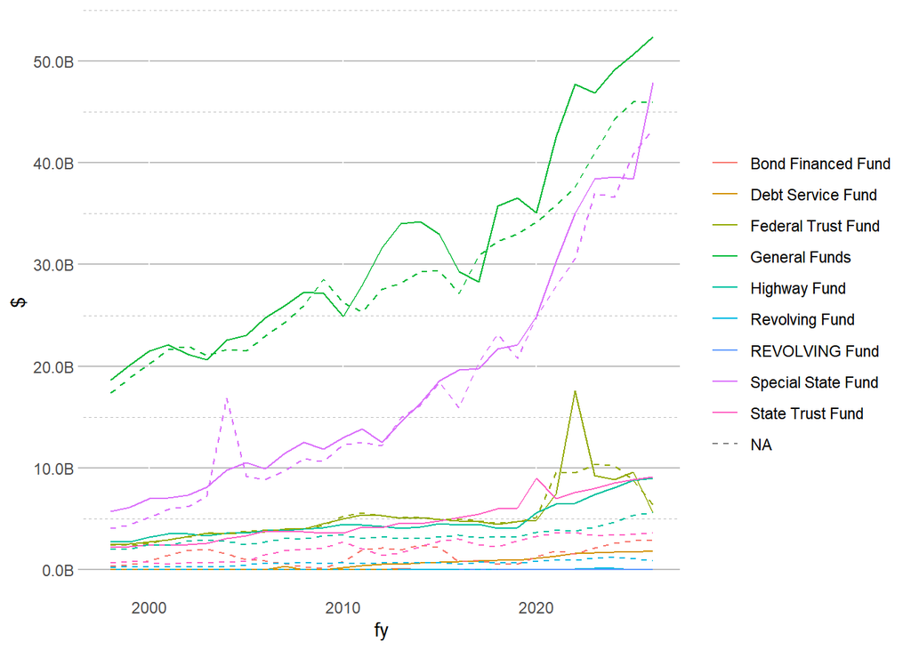

```
# A tibble: 1 × 3
# Groups:   fy [1]
     fy fund_cat_name      Revenue
  <dbl> <chr>                <dbl>
1  2026 General Funds 52413032215.
```

```
# A tibble: 1 × 3
# Groups:   fy [1]
     fy fund_cat_name Expenditures
  <dbl> <chr>                <dbl>
1  2026 General Funds 45956535437.
```

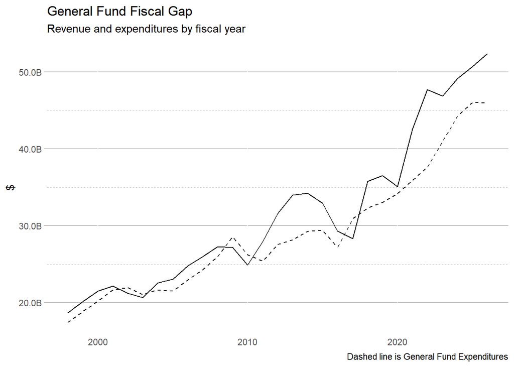

### Graphs and Tables

##### Fiscal Gap Graph

Figure 1: Fiscal Gap Comparison

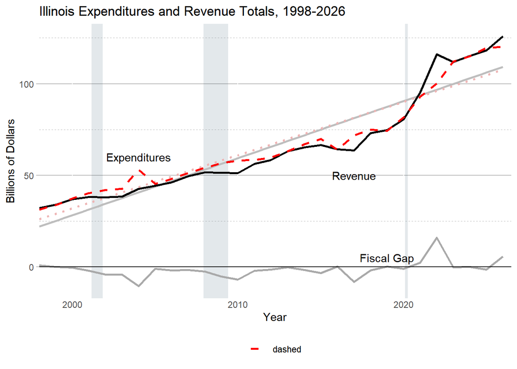

(a) Fiscal Gap With Trend Lines

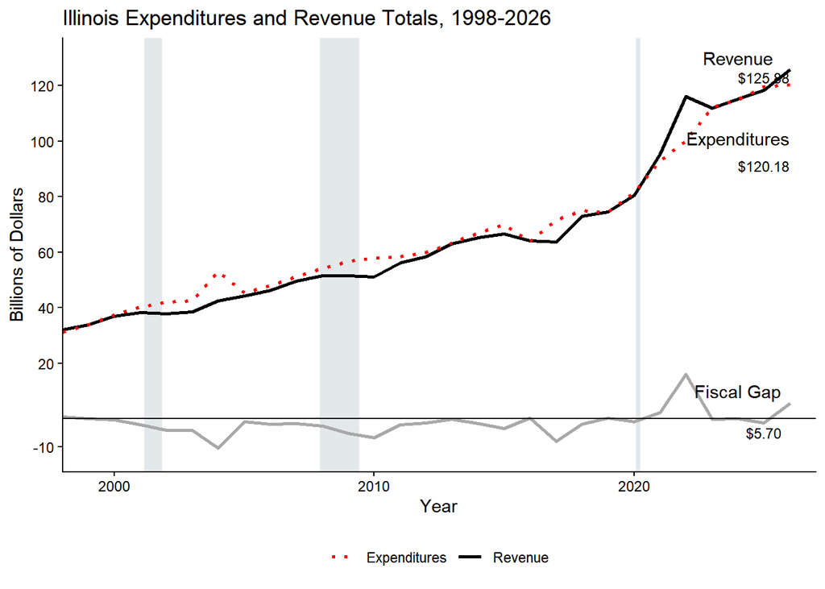

(b) Fiscal Gap Without Trend Lines

#### Downloadable Tables

Table 1: Fiscal Futures Revenue Categories. As of March 2026, this is now the downloadable table on IGPA Datahub site. Totals are in millions of nominal dollars.

| Category | Category_name | 1998 | 1999 | 2000 | 2001 | 2002 | 2003 | 2004 | 2005 | 2006 | 2007 | 2008 | 2009 | 2010 | 2011 | 2012 | 2013 | 2014 | 2015 | 2016 | 2017 | 2018 | 2019 | 2020 | 2021 | 2022 | 2023 | 2024 | 2025 | … |
| --- | --- | --- | --- | --- | --- | --- | --- | --- | --- | --- | --- | --- | --- | --- | --- | --- | --- | --- | --- | --- | --- | --- | --- | --- | --- | --- | --- | --- | --- | --- |
| 02 | Individual Income Taxes | 6847 | 7226 | 7686 | 7996 | 7471 | 7341 | 7272 | 7979 | 8635 | 9408 | 10320 | 9223 | 8510 | 11225 | 15512 | 16539 | 16642 | 15914 | 13807 | 13662 | 18748 | 20411 | 19601 | 23980 | 26441 | 25310 | 27378 | 30125 | … |
| 03 | Corporate Income Taxes | 1860 | 1855 | 2068 | 1790 | 1384 | 1293 | 1596 | 1972 | 2400 | 2936 | 3116 | 2752 | 2196 | 2986 | 3482 | 4448 | 4435 | 4054 | 3192 | 2747 | 3452 | 3989 | 3637 | 5992 | 10027 | 10484 | 8302 | 6955 | … |
| 06 | Sales Taxes | 7198 | 7647 | 8218 | 8175 | 8279 | 8228 | 8637 | 8981 | 9638 | 9785 | 9994 | 9298 | 8789 | 9514 | 10003 | 10236 | 10654 | 11148 | 11307 | 11385 | 11745 | 12457 | 12273 | 13898 | 15474 | 16222 | 16426 | 16701 | … |
| 09 | Motor Fuel Tax | 1301 | 1329 | 1356 | 1367 | 1374 | 1388 | 1424 | 1435 | 1446 | 1454 | 1335 | 1467 | 1339 | 1314 | 1290 | 1260 | 1294 | 1293 | 1354 | 1348 | 1368 | 1351 | 2319 | 2384 | 2527 | 2569 | 2822 | 2954 | … |
| 12 | Public Utility Taxes | 1193 | 1423 | 1524 | 1606 | 1568 | 1439 | 1536 | 1501 | 1550 | 1604 | 1636 | 1667 | 1572 | 1624 | 1481 | 1507 | 1454 | 1476 | 1406 | 1396 | 1431 | 1474 | 1424 | 1369 | 1412 | 1443 | 1439 | 1478 | … |
| 15 | Cigarette Taxes | 464 | 499 | 467 | 473 | 469 | 700 | 760 | 656 | 640 | 639 | 614 | 582 | 582 | 588 | 606 | 856 | 860 | 862 | 845 | 782 | 764 | 769 | 851 | 917 | 841 | 785 | 708 | 661 | … |
| 18 | Liquor Gallonage Taxes | 57 | 57 | 128 | 124 | 122 | 123 | 127 | 147 | 152 | 156 | 158 | 158 | 176 | 182 | 279 | 280 | 280 | 283 | 288 | 294 | 296 | 297 | 303 | 312 | 320 | 316 | 311 | 303 | … |
| 21 | Inheritance Tax | 250 | 347 | 348 | 361 | 329 | 237 | 222 | 310 | 272 | 264 | 373 | 288 | 243 | 122 | 235 | 293 | 276 | 333 | 306 | 261 | 358 | 388 | 283 | 450 | 603 | 503 | 627 | 603 | … |
| 24 | Insurance Taxes, Fees &amp; Licenses | 132 | 249 | 260 | 293 | 323 | 371 | 469 | 433 | 403 | 407 | 399 | 438 | 424 | 422 | 444 | 454 | 454 | 468 | 519 | 530 | 561 | 522 | 477 | 632 | 608 | 658 | 659 | 747 | … |
| 27 | Corp Franchise Taxes &amp; Fees | 121 | 119 | 141 | 148 | 162 | 145 | 167 | 186 | 186 | 198 | 231 | 207 | 213 | 212 | 197 | 209 | 208 | 216 | 212 | 212 | 212 | 253 | 215 | 328 | 221 | 231 | 208 | 202 | … |

[output cut: 15 more lines]

**Pensions within agencies**

Table 2: Fiscal Futures Grouped Expenditure Categories. As of March 2026, this is now the downloadable table on IGPA Datahub site. Totals are in millions of nominal dollars.

| Category | Category_name | 1998 | 1999 | 2000 | 2001 | 2002 | 2003 | 2004 | 2005 | 2006 | 2007 | 2008 | 2009 | 2010 | 2011 | 2012 | 2013 | 2014 | 2015 | 2016 | 2017 | 2018 | 2019 | 2020 | 2021 | 2022 | 2023 | 2024 | 2025 | … |
| --- | --- | --- | --- | --- | --- | --- | --- | --- | --- | --- | --- | --- | --- | --- | --- | --- | --- | --- | --- | --- | --- | --- | --- | --- | --- | --- | --- | --- | --- | --- |
| 402 | Aging | 215 | 236 | 261 | 284 | 298 | 304 | 314 | 403 | 421 | 489 | 527 | 607 | 728 | 715 | 796 | 1121 | 994 | 1032 | 711 | 1256 | 954 | 988 | 1065 | 1144 | 1174 | 1380 | 1543 | 1727 | … |
| 406 | Agriculture | 75 | 90 | 105 | 117 | 118 | 93 | 84 | 75 | 84 | 85 | 87 | 81 | 83 | 74 | 72 | 72 | 75 | 73 | 58 | 72 | 87 | 79 | 74 | 69 | 92 | 92 | 112 | 139 | … |
| 416 | Central Management | 427 | 474 | 488 | 495 | 491 | 499 | 586 | 721 | 696 | 720 | 738 | 719 | 809 | 789 | 768 | 920 | 934 | 893 | 748 | 1147 | 1012 | 951 | 1190 | 1191 | 1159 | 1364 | 1397 | 1525 | … |
| 418 | Children &amp; Family Services | 1300 | 1346 | 1359 | 1375 | 1363 | 1301 | 1268 | 1238 | 1241 | 1264 | 1270 | 1284 | 1231 | 1213 | 1191 | 1137 | 1129 | 1118 | 1087 | 1076 | 1085 | 1153 | 1239 | 1303 | 1252 | 1578 | 1794 | 1922 | … |
| 420 | Commerce &amp; Economic Opportunity | 465 | 526 | 707 | 765 | 813 | 831 | 928 | 424 | 595 | 601 | 441 | 521 | 1179 | 1160 | 1027 | 980 | 1052 | 994 | 513 | 649 | 498 | 576 | 620 | 1676 | 1391 | 1498 | 1611 | 1836 | … |
| 422 | Natural Resources | 199 | 237 | 278 | 319 | 360 | 324 | 283 | 249 | 246 | 270 | 249 | 233 | 226 | 235 | 228 | 244 | 279 | 312 | 176 | 232 | 254 | 283 | 278 | 291 | 292 | 322 | 382 | 444 | … |
| 426 | Corrections | 987 | 1104 | 1190 | 1271 | 1332 | 1245 | 1256 | 1285 | 1244 | 1202 | 1290 | 1374 | 1228 | 1271 | 1282 | 1253 | 1355 | 1386 | 956 | 1275 | 1949 | 1583 | 1538 | 1613 | 1502 | 1704 | 1828 | 1883 | … |
| 427 | Employment Security | 181 | 184 | 189 | 292 | 350 | 388 | 220 | 205 | 207 | 200 | 209 | 239 | 283 | 320 | 270 | 266 | 251 | 218 | 205 | 194 | 237 | 221 | 237 | 327 | 275 | 271 | 266 | 284 | … |
| 442 | Human Rights | 9 | 8 | 9 | 8 | 9 | 9 | 8 | 9 | 8 | 10 | 12 | 12 | 10 | 12 | 12 | 12 | 13 | 13 | 11 | 12 | 11 | 13 | 12 | 13 | 13 | 14 | 16 | 20 | … |
| 444 | Human Services | 3934 | 4129 | 4238 | 4559 | 4574 | 4483 | 4664 | 4796 | 4863 | 4974 | 5223 | 5433 | 5413 | 5710 | 5272 | 5612 | 5628 | 5902 | 5066 | 5410 | 5436 | 5623 | 5997 | 6550 | 7277 | 8830 | 10467 | 11255 | … |

[output cut: 26 more lines]

**Pensions separately**

Table 3: Fiscal Futures Grouped Expenditure Categories. As of March 2026, this is now the downloadable table on IGPA Datahub site. Totals are in millions of nominal dollars.

| Category | Category_name | 1998 | 1999 | 2000 | 2001 | 2002 | 2003 | 2004 | 2005 | 2006 | 2007 | 2008 | 2009 | 2010 | 2011 | 2012 | 2013 | 2014 | 2015 | 2016 | 2017 | 2018 | 2019 | 2020 | 2021 | 2022 | 2023 | 2024 | 2025 | … |
| --- | --- | --- | --- | --- | --- | --- | --- | --- | --- | --- | --- | --- | --- | --- | --- | --- | --- | --- | --- | --- | --- | --- | --- | --- | --- | --- | --- | --- | --- | --- |
| 402 | Aging | 215 | 236 | 261 | 284 | 297 | 304 | 314 | 402 | 420 | 488 | 527 | 606 | 728 | 715 | 795 | 1121 | 994 | 1032 | 710 | 1256 | 954 | 988 | 1065 | 1143 | 1174 | 1380 | 1542 | 1726 | … |
| 406 | Agriculture | 74 | 88 | 103 | 115 | 115 | 90 | 82 | 71 | 82 | 83 | 84 | 77 | 81 | 72 | 70 | 70 | 72 | 70 | 55 | 69 | 84 | 75 | 71 | 66 | 89 | 89 | 109 | 135 | … |
| 416 | Central Management | 424 | 470 | 483 | 489 | 485 | 493 | 579 | 710 | 689 | 709 | 722 | 698 | 784 | 768 | 739 | 891 | 903 | 860 | 719 | 1140 | 998 | 936 | 1190 | 1191 | 1159 | 1364 | 1397 | 1525 | … |
| 418 | Children &amp; Family Services | 1290 | 1329 | 1342 | 1357 | 1345 | 1282 | 1252 | 1210 | 1227 | 1243 | 1238 | 1245 | 1231 | 1213 | 1191 | 1137 | 1129 | 1118 | 1087 | 1076 | 1085 | 1153 | 1239 | 1303 | 1252 | 1578 | 1794 | 1922 | … |
| 420 | Commerce &amp; Economic Opportunity | 464 | 524 | 705 | 763 | 811 | 830 | 926 | 422 | 594 | 599 | 438 | 518 | 1176 | 1158 | 1026 | 980 | 1052 | 994 | 513 | 649 | 498 | 576 | 620 | 1676 | 1391 | 1498 | 1611 | 1836 | … |
| 422 | Natural Resources | 195 | 231 | 271 | 312 | 352 | 316 | 276 | 239 | 241 | 262 | 237 | 219 | 216 | 224 | 215 | 231 | 263 | 298 | 163 | 220 | 241 | 268 | 263 | 273 | 273 | 308 | 365 | 427 | … |
| 426 | Corrections | 959 | 1046 | 1127 | 1202 | 1258 | 1173 | 1195 | 1173 | 1187 | 1125 | 1170 | 1220 | 1225 | 1268 | 1278 | 1249 | 1351 | 1382 | 951 | 1275 | 1945 | 1579 | 1534 | 1611 | 1502 | 1704 | 1828 | 1883 | … |
| 427 | Employment Security | 176 | 176 | 181 | 282 | 340 | 377 | 208 | 190 | 200 | 189 | 193 | 218 | 250 | 287 | 230 | 227 | 251 | 218 | 205 | 194 | 237 | 221 | 237 | 327 | 275 | 271 | 266 | 284 | … |
| 442 | Human Rights | 8 | 8 | 8 | 8 | 8 | 8 | 8 | 8 | 8 | 9 | 11 | 11 | 10 | 12 | 12 | 12 | 12 | 12 | 11 | 11 | 10 | 13 | 12 | 13 | 13 | 14 | 16 | 20 | … |
| 444 | Human Services | 3889 | 4060 | 4167 | 4484 | 4496 | 4410 | 4600 | 4688 | 4811 | 4893 | 5104 | 5279 | 5392 | 5689 | 5246 | 5584 | 5600 | 5872 | 5036 | 5383 | 5405 | 5593 | 5964 | 6516 | 7241 | 8796 | 10431 | 11218 | … |

[output cut: 27 more lines]

**Expenditure and revenue amounts in billions of dollars:**

**Pensions within agencies**

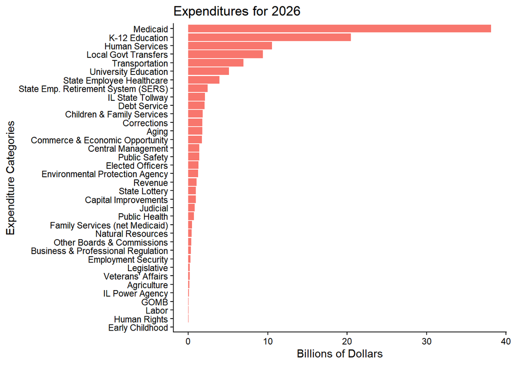

(a) FY2026 Expenditures

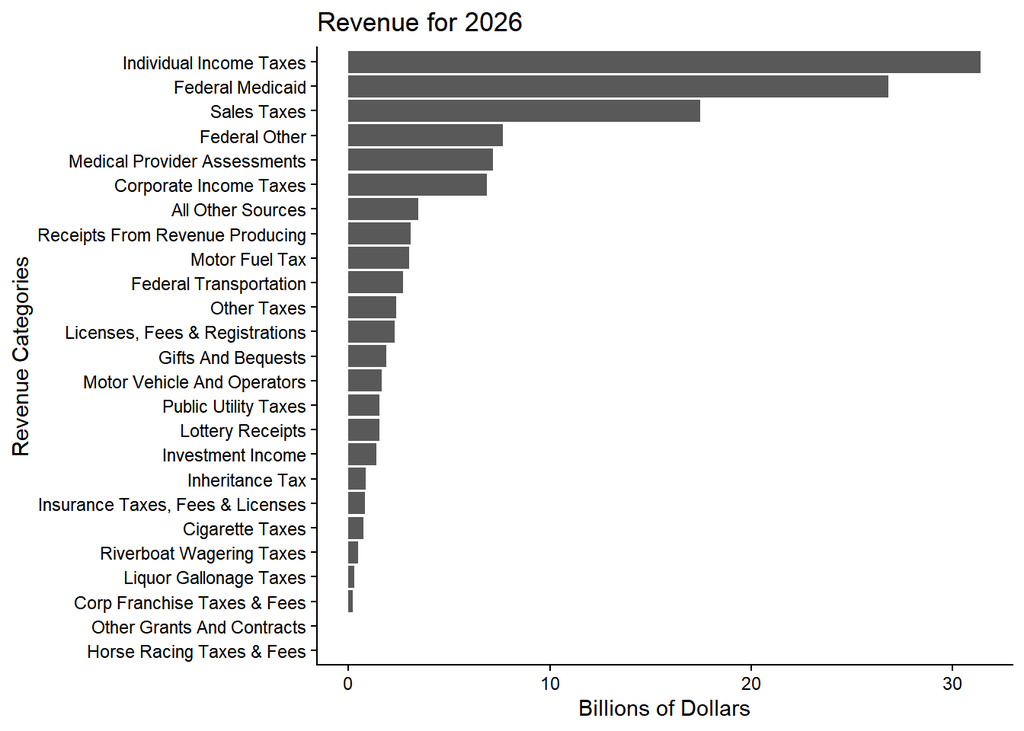

(b) FY2026 Revenue Sources

Figure 2: FY2026 Totals

**Pensions separately**

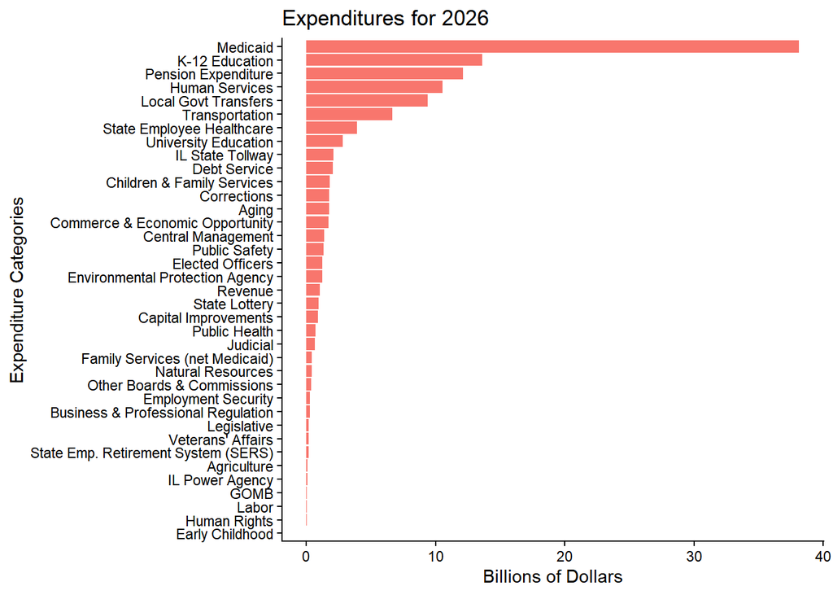

(a) FY2026 Expenditures

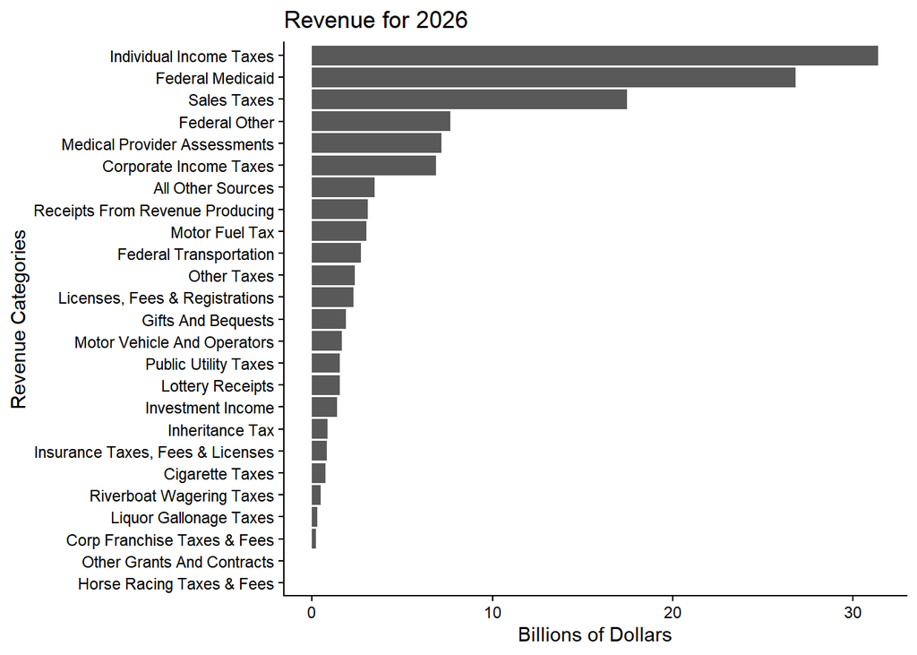

(b) FY2026 Revenue Sources

Figure 3: FY2026 Totals

**Expenditure and revenues when focusing on largest categories and combining others into “All Other Expenditures(Revenues)”:**

**Pensions within agencies**

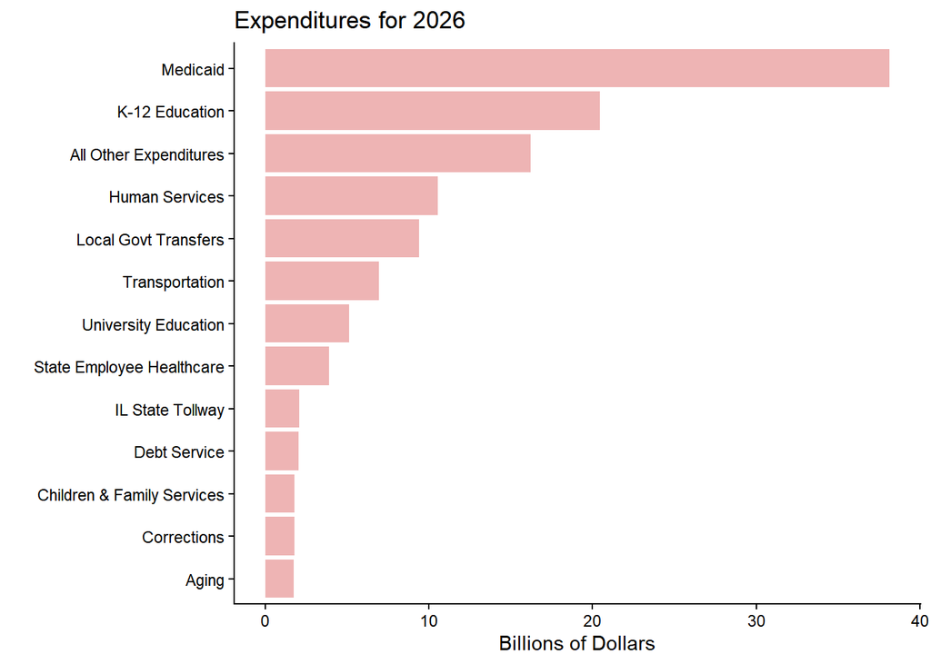

(a) Largest Expenditures for FY2026

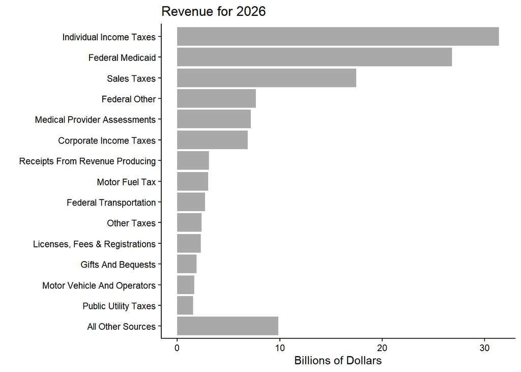

(b) Largest Revenue Sources for FY2026

Figure 4: Largest Groups

**Pensions separately**

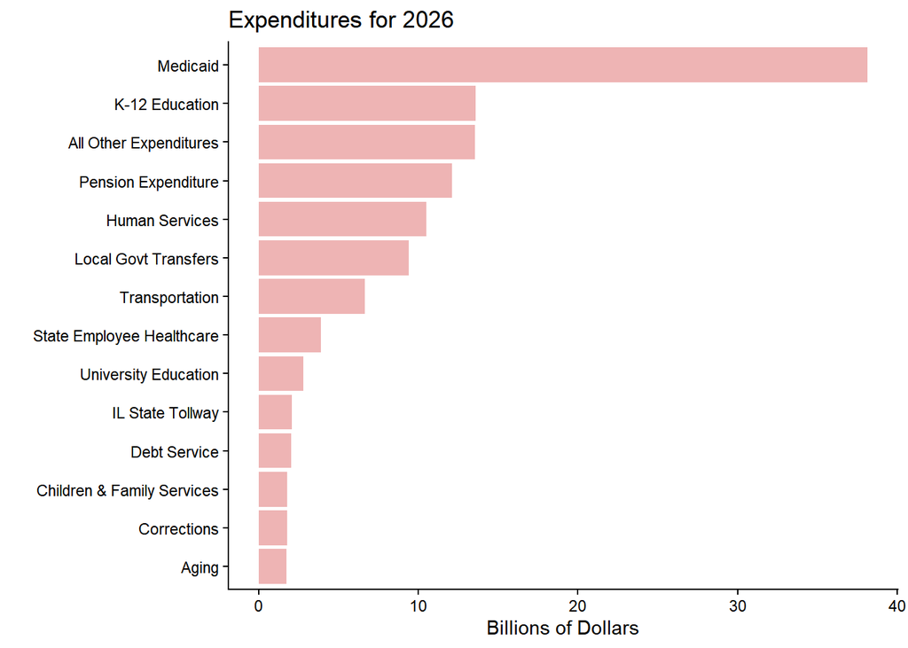

(a) Largest Expenditures for FY2026

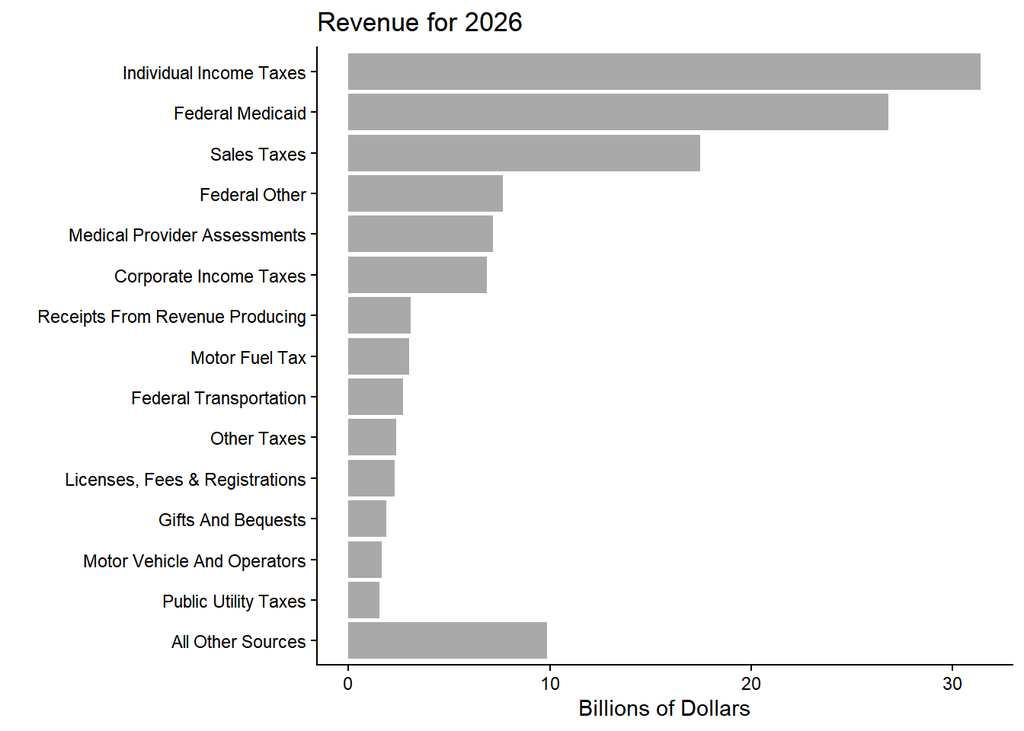

(b) Largest Revenue Sources for FY2026

Figure 5: Largest Groups

**Pensions within agencies**

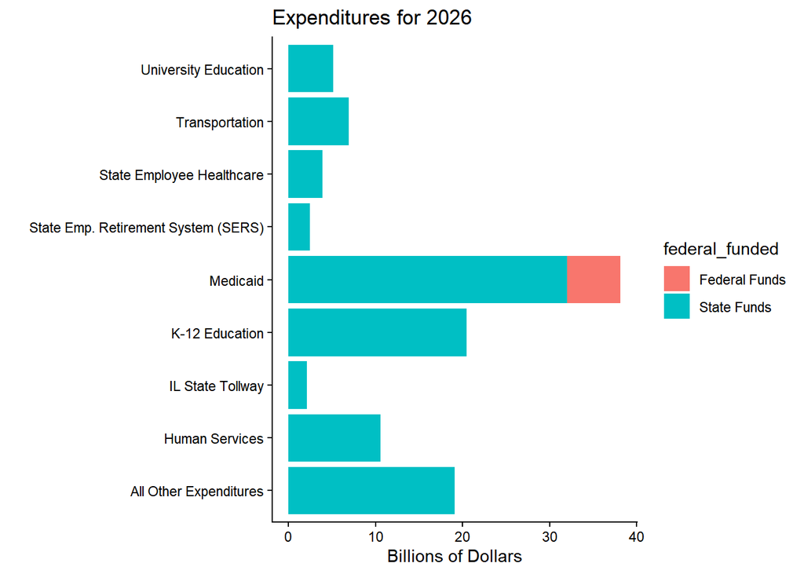

Figure 6: Largest Expenditure Categories for FY 2026

**Pensions separately**

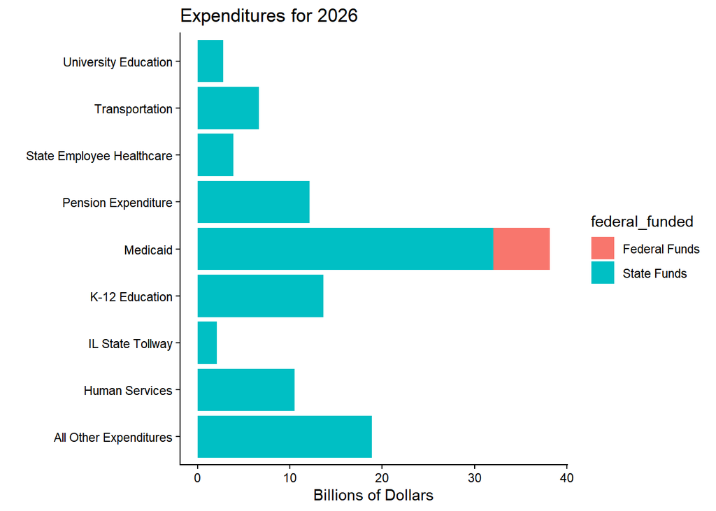

Figure 7: Largest Expenditure Categories for FY 2026

##### Major Revenue Trends

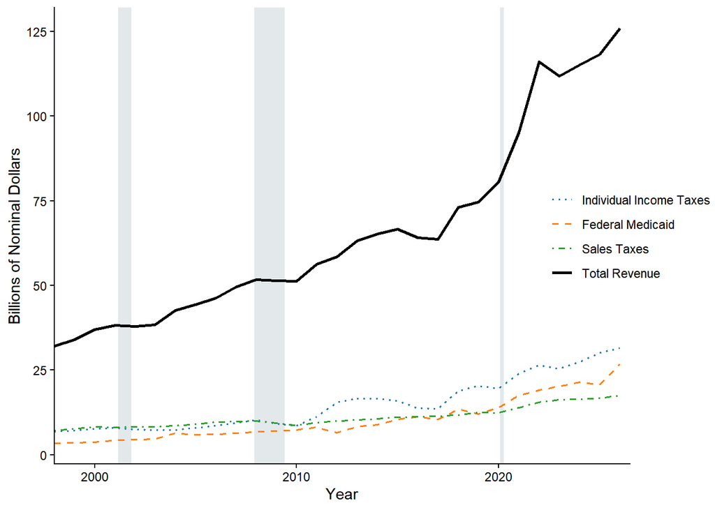

Figure 8: Top 3 Revenue Sources

Figure 9: Top 3 Own-Source Revenue Sources

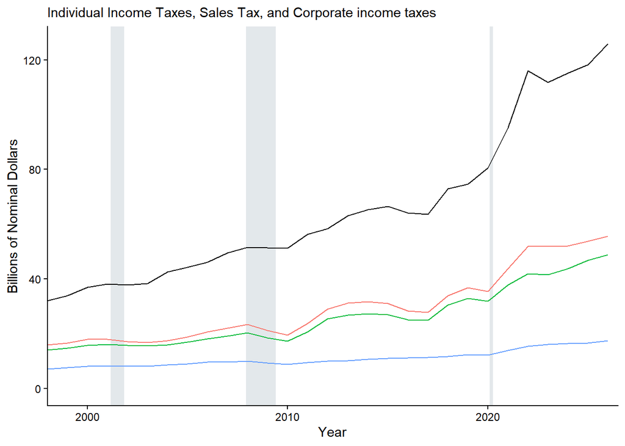

##### Own Source and Fed Transfers

Federal revenue to all fund types is coded as 3 types of federal revenue: Medicaid, Transportation, and Other.

Table 4: Own Source and Federal Revenue

```
# A tibble: 29 × 2
    Year Dollars
   <dbl>   <dbl>
 1  1998  24106.
 2  1999  25713.
 3  2000  28118.
 4  2001  28594.
 5  2002  27860.
 6  2003  27917.
 7  2004  29681.
 8  2005  32134.
 9  2006  33817.
10  2007  36386.
# ℹ 19 more rows
```

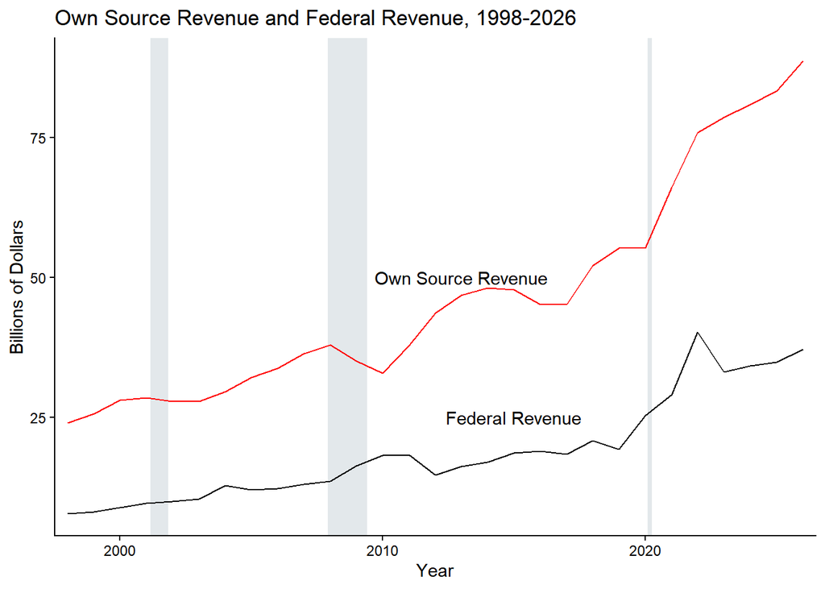

##### Medicaid Reimbursements and Expenditures

**Historical FY2025 notes (not current-year findings):**

Key funds: Healthcare Provider Relief (0793) and Hospital Provider (0346) 0365 is Health and Human Services Medicaid TR ? 0740 is Medicaid Buy in Program

Healthcare provider taxes come from revenue source 0133.

2104 = Medicare Part D 2683 = MCO Provider Assessment –> Mostly goes to Healthcare Provider Relief Fund 0793 in HFS 2526 = Hospital Provider Fund (not used in fy2025)

0133 = Health Care Provider Tax –> Mostly goes to Hospital Provider Fund 0346 0137 = Health Care Prov-Hospital (not used in fy2025) 0145 = IHFA Medicaid Provider (not used in fy2025)

**Illinois also received:**

- over 500 million for TANF grant (source = 1393).
- Also receives food stamp funds, over 500 million for “Medical Administration” source 0675. This mostly goes to the General Revenue Fund.
- around $1.3 billion for “Medical Assistance” (source 0692, which goes to Drug Rebate Fund 0728)
- an additional $3.3 billion in medical assistance from source 0676 which mostly goes to the General Revenue fund (0001) and a little goes to Tobacco settlement recovery fund

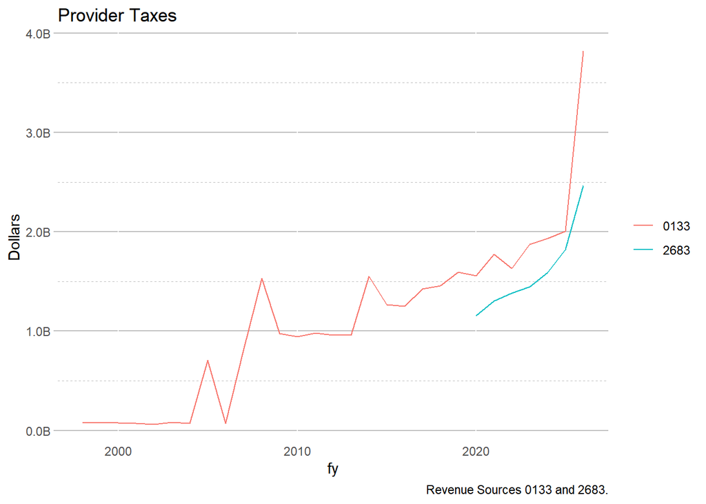

```
# A tibble: 2 × 3
# Groups:   fy [1]
     fy fund_name_ab                     receipts
  <dbl> <chr>                               <dbl>
1  2026 CARE PROV FOR PERSONS WITH DD   24669118.
2  2026 HOSPITAL PROVIDER             3793352676.
```

```
# A tibble: 1 × 1
        spent
        <dbl>
1 7229161454.
```

```
# A tibble: 3 × 42
     fy fund  agency agency_name   appr_org org_name obj_seq_type wh_approp_name
  <dbl> <chr> <chr>  <chr>         <chr>    <chr>    <chr>        <chr>
1  2026 0346  478    Healthcare &… 65       MEDICAL  44000098     HOSPITALS, CA…
2  2026 0346  478    Healthcare &… 65       MEDICAL  99390000     REFUNDS
3  2026 0346  478    Healthcare &… 65       MEDICAL  19910098     PROMPT PAYMEN…
# ℹ 34 more variables: appn_net_xfer <dbl>, expenditure <dbl>,
#   data_source <chr>, fund_ab <chr>, fund_ioc <chr>, fund_re <dbl>,
#   a_end <dbl>, activefy2025 <dbl>, activefy2025_rev <dbl>, in_ff <chr>,
#   fund_name_ab <chr>, fund_category <chr>, fund_cat_name <chr>,
#   effective_date <date>, transfer <dbl>, trans_agency <dbl>,
#   trans_type <chr>, object <chr>, sequence <chr>, type <chr>,
#   original_agency <chr>, original_object <chr>, original_in_ff <dbl>, …
```

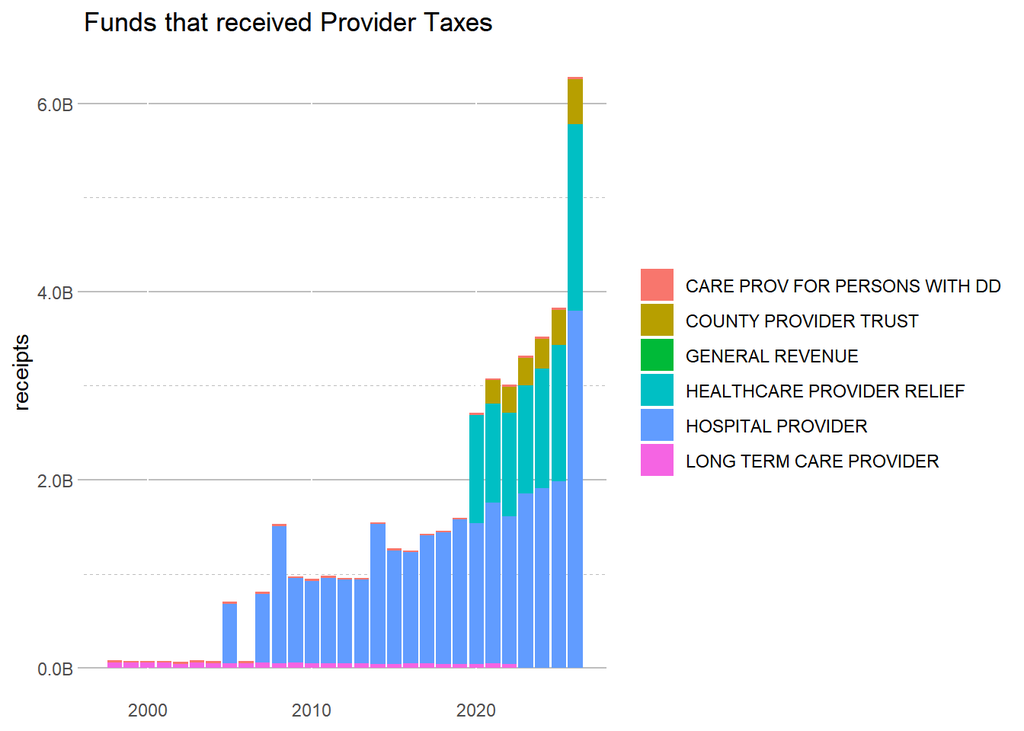

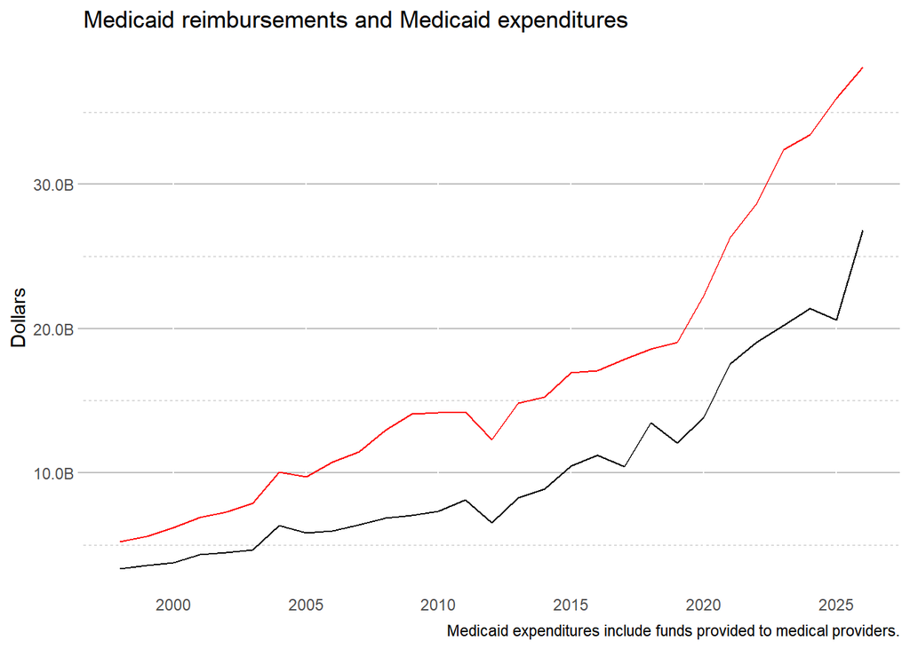

##### Provider Assessments, % of 1998 levels

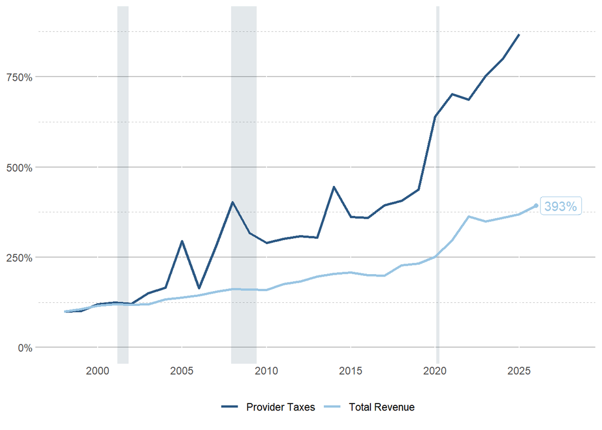

Figure 10

### Change from Previous Year

**Pensions within agencies**

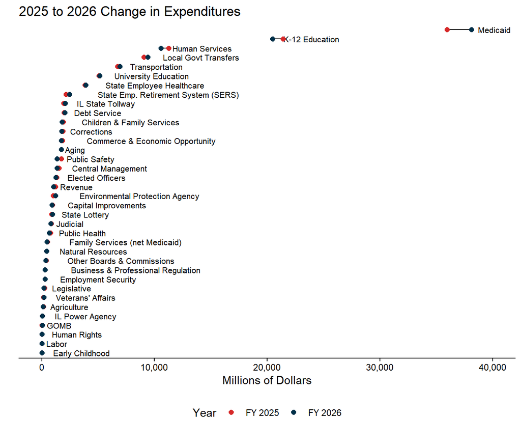

Figure 11

**Pensions separately**

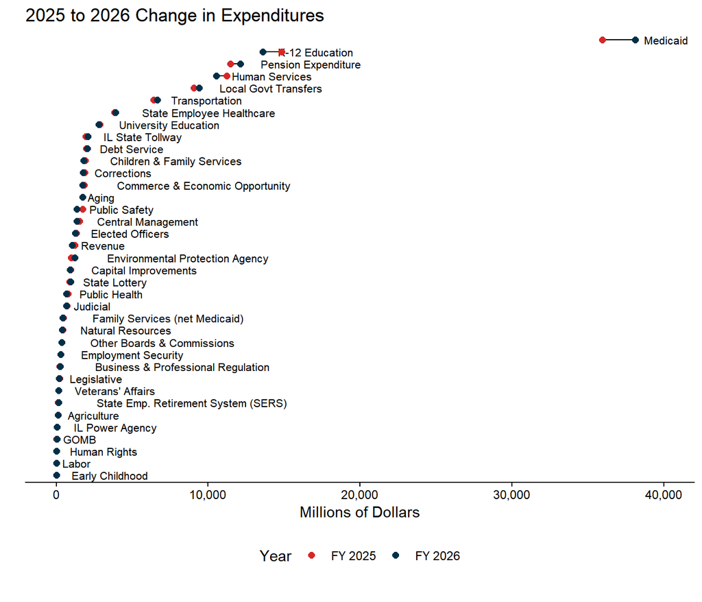

Figure 12

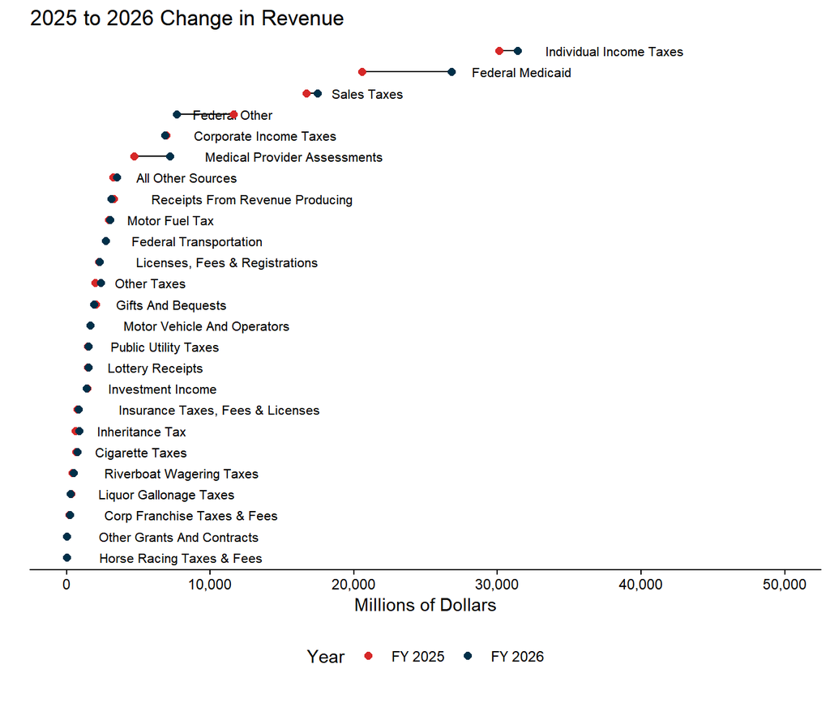

Figure 13

Year comparisons and CAGR endpoints follow the selected report year automatically. The full-period historical baseline remains FY1998.

`calc_cagr` is a function created for calculating the CAGRs for different spans of time.

The full-period CAGR spans 1998 through the selected report year.

**Pensions within agencies**

Table 5: Expenditure Category CAGRs with Total CAGR (Ordered Alphabetically)

CAGR Calculations for All Expenditure Categories

[output not shown]

**Pensions separately**

Table 6: Expenditure Category CAGRs with Total CAGR (Ordered Alphabetically)

CAGR Calculations for All Expenditure Categories

| Expenditure Category | Full Period CAGR | 10 Year CAGR | 5 Year CAGR | 3 Year CAGR | 2 Year CAGR | 1 Year CAGR |
| --- | --- | --- | --- | --- | --- | --- |
| Aging | 7.76 | 9.38 | 8.78 | 8.07 | 6.27 | 0.89 |
| Agriculture | 1.17 | 6.27 | 9.06 | 4.80 | -3.14 | -24.27 |
| Business & Professional Regulation | 1.94 | 2.82 | 10.19 | 11.62 | 13.65 | 12.78 |
| Capital Improvement | 4.64 | 25.94 | 15.11 | 12.20 | 5.42 | -3.16 |
| Central Management | 4.29 | 6.67 | 2.86 | 0.18 | -0.91 | -10.03 |
| Children & Family Services | 1.21 | 5.22 | 6.77 | 4.64 | 0.39 | -5.93 |
| Commerce and Economic Development | 4.80 | 12.88 | 0.53 | 4.73 | 3.38 | -6.26 |
| Corrections | 2.22 | 6.44 | 1.96 | 1.37 | -1.46 | -5.72 |
| Debt Service | 5.27 | 0.67 | 0.12 | 1.47 | -5.62 | 3.87 |
| Early Childhood | Inf | Inf | Inf | Inf | Inf | Inf |
| Elected Officials | 4.13 | 6.14 | 5.79 | 5.80 | 2.72 | -5.55 |
| Employment Security | 1.72 | 3.28 | -2.83 | 1.53 | 3.29 | -0.03 |
| Environmental Protection Agency | 5.01 | 4.19 | 12.92 | 25.86 | 17.87 | 22.04 |
| Healthcare & Family Services (Net Medicaid) | 4.86 | 2.53 | 3.06 | 2.30 | -1.28 | -9.77 |
| Human Services | 3.62 | 7.65 | 10.06 | 6.16 | 0.45 | -6.18 |
| Judicial | 3.30 | 5.35 | 4.73 | 2.24 | 0.61 | -6.90 |
| K-12 Education | 3.59 | 3.84 | 1.98 | -2.88 | -5.82 | -8.31 |
| Legislative | 3.83 | 6.77 | 9.96 | -6.97 | -11.34 | -24.17 |
| Local Govt Revenue Sharing | 3.61 | 4.19 | 5.52 | -4.85 | -1.39 | 3.84 |
| Medicaid | 7.23 | 8.39 | 7.73 | 5.57 | 6.77 | 6.07 |
| Natural Resources | 2.61 | 9.45 | 7.99 | 9.24 | 4.89 | -5.99 |
| Other Boards & Commissions | 4.98 | 5.76 | 8.60 | 4.39 | 3.35 | -2.00 |
| Other Departments | 3.10 | 17.17 | 18.10 | 21.00 | 5.34 | 12.73 |
| Pension Expenditure | 9.58 | 5.20 | 4.43 | 3.17 | 5.26 | 5.65 |
| Public Health | 5.35 | 7.16 | -6.14 | -3.57 | -2.92 | -12.58 |
| Public Safety | 4.20 | 6.38 | -7.53 | -7.97 | -21.12 | -22.13 |
| Revenue | 3.17 | 9.54 | -9.29 | -30.47 | -12.70 | -15.11 |
| State Employee Healthcare | 6.17 | 23.36 | 6.27 | 9.16 | 11.13 | 2.38 |
| State Employment Retirement (SERS) | 29.61 | 128.72 | 16.50 | 9.64 | 35.23 | 20.46 |
| State Lottery | 4.29 | 5.62 | 6.01 | -12.69 | -3.61 | 4.80 |
| Tollway | 6.40 | -0.73 | 1.23 | 3.29 | 2.75 | 8.41 |
| Transportation | 4.47 | 4.87 | 5.33 | 9.65 | 8.63 | 4.01 |
| University Education | 1.08 | 12.49 | 5.00 | 3.35 | -1.18 | -1.70 |
| Veterans' Affairs | 4.11 | 4.61 | 6.74 | 7.91 | 5.16 | 4.27 |
| Total | 4.93 | 6.52 | 5.29 | 2.39 | 2.23 | 0.56 |

Table 7: Revenue Category CAGRs with Total CAGR (Ordered Alphabetically)

CAGR Calculations for All Revenue Sources (Ordered Alphabetical)

| Revenue Category | Full Period CAGR | 10 Year CAGR | 5 Year CAGR | 3 Year CAGR | 2 Year CAGR | 1 Year CAGR |
| --- | --- | --- | --- | --- | --- | --- |
| Cigarette Taxes | 1.66 | -1.37 | -4.30 | -2.12 | 1.96 | 11.28 |
| Corp Franchise Taxes & Fees | 2.07 | 0.08 | -8.18 | -2.48 | 1.53 | 5.84 |
| Corporate Income Taxes | 4.78 | 7.97 | 2.77 | -13.15 | -9.04 | -1.23 |
| Federal Medicaid | 7.72 | 9.08 | 8.84 | 9.89 | 12.00 | 30.27 |
| Federal Other | 2.60 | 2.67 | -3.57 | -10.95 | -14.42 | -33.83 |
| Federal Transportation | 4.29 | 3.91 | 2.62 | 8.60 | 7.11 | -1.20 |
| Gifts And Bequests | 9.82 | 7.34 | 4.90 | -3.21 | -11.82 | -7.05 |
| Horse Racing Taxes & Fees | -6.14 | 0.69 | -3.86 | -2.24 | -3.95 | -7.16 |
| Individual Income Taxes | 5.59 | 8.56 | 5.54 | 7.45 | 7.09 | 4.23 |
| Inheritance Tax | 4.55 | 11.03 | 14.12 | 20.10 | 17.80 | 44.45 |
| Insurance Taxes, Fees & Licenses | 6.71 | 4.62 | 5.24 | 7.45 | 11.27 | 9.14 |
| Investment Income | 5.89 | 38.23 | 67.97 | 22.56 | 4.47 | -3.14 |
| Licenses, Fees & Registrations | 7.48 | 6.55 | 3.13 | 3.72 | -1.12 | 1.53 |
| Liquor Gallonage Taxes | 6.04 | 0.24 | -1.13 | -2.31 | -2.65 | -2.70 |
| Lottery Receipts | 2.21 | 1.67 | 0.72 | -0.42 | -2.11 | 5.15 |
| Medical Provider Assessments | 9.66 | 13.92 | 13.54 | 20.69 | 28.66 | 52.50 |
| Motor Fuel Tax | 3.04 | 8.32 | 4.78 | 5.43 | 3.29 | 1.94 |
| Motor Vehicle And Operators | 2.91 | 0.72 | -0.29 | 1.45 | 0.92 | 1.69 |
| Other Grants And Contracts | 4.83 | 24.16 | 86.11 | 80.38 | 97.61 | 82.74 |
| Other Taxes | 8.47 | 13.13 | 21.96 | 13.36 | 18.32 | 18.93 |
| Public Utility Taxes | 0.92 | 0.93 | 2.39 | 2.21 | 3.48 | 4.31 |
| Receipts From Revenue Producing | 5.33 | 3.54 | 6.07 | 6.32 | 1.64 | -5.28 |
| Riverboat Wagering Taxes | 3.14 | 1.24 | 23.15 | 12.74 | 17.70 | 19.86 |
| Sales Taxes | 3.21 | 4.44 | 4.66 | 2.47 | 3.08 | 4.50 |
| All Other Sources | 6.44 | 8.39 | 13.52 | 1.73 | 3.06 | 8.07 |
| Total | 5.01 | 6.97 | 5.75 | 4.04 | 4.57 | 6.54 |

Table 8: Yearly Change in Revenues - All FF Categories, Ordered from Largest to Smallest Revenue Amount

Table 1. Yearly Change in Revenue (All Sources)

| Revenue Category | FY 2026 ($ billions) | FY 2025 ($ billions) | FY 1998 ($ billions) | 1-Year Change | Full Period CAGR |
| --- | --- | --- | --- | --- | --- |
| Individual Income Taxes | 31.40 | 30.13 | 6.85 | 4.23% | 5.59% |
| Federal Medicaid | 26.81 | 20.58 | 3.34 | 30.27% | 7.72% |
| Sales Taxes | 17.45 | 16.70 | 7.20 | 4.50% | 3.21% |
| Federal Other | 7.68 | 11.61 | 3.75 | -33.83% | 2.60% |
| Medical Provider Assessments | 7.19 | 4.71 | 0.54 | 52.50% | 9.66% |
| Corporate Income Taxes | 6.87 | 6.95 | 1.86 | -1.23% | 4.78% |
| Receipts From Revenue Producing | 3.11 | 3.28 | 0.73 | -5.28% | 5.33% |
| Motor Fuel Tax | 3.01 | 2.95 | 1.30 | 1.94% | 3.04% |
| Federal Transportation | 2.71 | 2.74 | 0.84 | -1.20% | 4.29% |
| Other Taxes | 2.39 | 2.01 | 0.24 | 18.93% | 8.47% |
| Licenses, Fees & Registrations | 2.30 | 2.26 | 0.30 | 1.53% | 7.48% |
| Gifts And Bequests | 1.90 | 2.05 | 0.14 | -7.05% | 9.82% |
| Motor Vehicle And Operators | 1.67 | 1.64 | 0.75 | 1.69% | 2.91% |
| Public Utility Taxes | 1.54 | 1.48 | 1.19 | 4.31% | 0.92% |
| Lottery Receipts | 1.54 | 1.46 | 0.83 | 5.15% | 2.21% |
| Investment Income | 1.38 | 1.42 | 0.28 | -3.14% | 5.89% |
| Inheritance Tax | 0.87 | 0.60 | 0.25 | 44.45% | 4.55% |
| Insurance Taxes, Fees & Licenses | 0.82 | 0.75 | 0.13 | 9.14% | 6.71% |
| Cigarette Taxes | 0.74 | 0.66 | 0.46 | 11.28% | 1.66% |
| Riverboat Wagering Taxes | 0.50 | 0.42 | 0.21 | 19.86% | 3.14% |
| Liquor Gallonage Taxes | 0.29 | 0.30 | 0.06 | -2.70% | 6.04% |
| Corp Franchise Taxes & Fees | 0.21 | 0.20 | 0.12 | 5.84% | 2.07% |
| Other Grants And Contracts | 0.01 | 0.01 | 0.00 | 82.74% | 4.83% |
| Horse Racing Taxes & Fees | 0.01 | 0.01 | 0.04 | -7.16% | -6.14% |
| All Other Sources | 3.49 | 3.23 | 0.61 | 8.07% | 6.44% |
| Total | 125.88 | 118.16 | 32.03 | 6.54% | 5.01% |

**Pensions within agencies**

Table 9: Yearly Change in Expenditures - All FF Categories, Ordered from Largest to Smallest Expenditure Amount

| Expenditure Category | FY 2026 ($ billions) | FY 2025 ($ billions) | FY 1998 ($ billions) | 1-Year Change | Full Period CAGR |
| --- | --- | --- | --- | --- | --- |
| Medicaid | 38.12 | 35.94 | 5.40 | 6.07% | 7.23% |
| K-12 Education | 20.46 | 21.40 | 5.60 | -4.35% | 4.73% |
| Human Services | 10.56 | 11.25 | 3.93 | -6.20% | 3.59% |
| Local Govt Revenue Sharing | 9.39 | 9.04 | 3.48 | 3.84% | 3.61% |
| Transportation | 6.93 | 6.70 | 1.98 | 3.41% | 4.58% |
| University Education | 5.13 | 5.08 | 2.28 | 1.15% | 2.94% |
| State Employee Healthcare | 3.91 | 3.81 | 0.73 | 2.38% | 6.17% |
| State Employment Retirement (SERS) | 2.45 | 2.15 | 0.01 | 13.98% | 22.02% |
| Tollway | 2.09 | 1.93 | 0.37 | 8.41% | 6.40% |
| Debt Service | 2.04 | 1.96 | 0.48 | 3.87% | 5.27% |
| Children & Family Services | 1.81 | 1.92 | 1.30 | -5.93% | 1.18% |
| Corrections | 1.78 | 1.88 | 0.99 | -5.72% | 2.12% |
| Aging | 1.74 | 1.73 | 0.22 | 0.90% | 7.76% |
| Commerce and Economic Development | 1.72 | 1.84 | 0.47 | -6.26% | 4.79% |
| Central Management | 1.37 | 1.52 | 0.43 | -10.03% | 4.26% |
| Public Safety | 1.36 | 1.75 | 0.44 | -21.98% | 4.15% |
| Elected Officials | 1.26 | 1.33 | 0.41 | -5.43% | 4.06% |
| Environmental Protection Agency | 1.22 | 1.00 | 0.31 | 21.70% | 5.01% |
| Revenue | 1.04 | 1.22 | 0.44 | -15.11% | 3.12% |
| State Lottery | 0.93 | 0.89 | 0.29 | 4.77% | 4.30% |
| Capital Improvement | 0.92 | 0.95 | 0.26 | -3.17% | 4.67% |
| Judicial | 0.81 | 0.85 | 0.28 | -5.32% | 3.81% |
| Public Health | 0.68 | 0.78 | 0.16 | -12.58% | 5.28% |
| Healthcare & Family Services (Net Medicaid) | 0.45 | 0.50 | 0.11 | -9.72% | 5.07% |
| Natural Resources | 0.41 | 0.44 | 0.20 | -6.69% | 2.65% |
| Other Boards & Commissions | 0.37 | 0.38 | 0.09 | -1.90% | 5.04% |
| Business & Professional Regulation | 0.30 | 0.28 | 0.15 | 9.17% | 2.46% |
| Employment Security | 0.28 | 0.28 | 0.18 | -0.03% | 1.61% |
| Legislative | 0.20 | 0.25 | 0.06 | -21.43% | 4.17% |
| Veterans' Affairs | 0.18 | 0.17 | 0.06 | 9.18% | 4.29% |
| Other Departments | 0.13 | 0.12 | 0.06 | 12.73% | 3.06% |
| Agriculture | 0.11 | 0.14 | 0.07 | -23.41% | 1.26% |
| Early Childhood | 0.00 | 0.00 | 0.00 | Inf | Inf |
| Total | 120.18 | 119.51 | 31.24 | 0.56% | 4.93% |

**Pensions separately**

Table 10: Yearly Change in Expenditures - All FF Categories, Ordered from Largest to Smallest Expenditure Amount

| Expenditure Category | FY 2026 ($ billions) | FY 2025 ($ billions) | FY 1998 ($ billions) | 1-Year Change | Full Period CAGR |
| --- | --- | --- | --- | --- | --- |
| Medicaid | 38.12 | 35.94 | 5.40 | 6.07% | 7.23% |
| K-12 Education | 13.61 | 14.84 | 5.07 | -8.31% | 3.59% |
| Pension Expenditure | 12.13 | 11.48 | 0.94 | 5.65% | 9.58% |
| Human Services | 10.52 | 11.22 | 3.89 | -6.18% | 3.62% |
| Local Govt Revenue Sharing | 9.39 | 9.04 | 3.48 | 3.84% | 3.61% |
| Transportation | 6.67 | 6.41 | 1.96 | 4.01% | 4.47% |
| State Employee Healthcare | 3.91 | 3.81 | 0.73 | 2.38% | 6.17% |
| University Education | 2.81 | 2.86 | 2.08 | -1.70% | 1.08% |
| Tollway | 2.09 | 1.93 | 0.37 | 8.41% | 6.40% |
| Debt Service | 2.04 | 1.96 | 0.48 | 3.87% | 5.27% |
| Children & Family Services | 1.81 | 1.92 | 1.29 | -5.93% | 1.21% |
| Corrections | 1.78 | 1.88 | 0.96 | -5.72% | 2.22% |
| Aging | 1.74 | 1.73 | 0.21 | 0.89% | 7.76% |
| Commerce and Economic Development | 1.72 | 1.84 | 0.46 | -6.26% | 4.80% |
| Central Management | 1.37 | 1.52 | 0.42 | -10.03% | 4.29% |
| Public Safety | 1.35 | 1.73 | 0.43 | -22.13% | 4.20% |
| Elected Officials | 1.25 | 1.33 | 0.40 | -5.55% | 4.13% |
| Environmental Protection Agency | 1.21 | 0.99 | 0.31 | 22.04% | 5.01% |
| Revenue | 1.04 | 1.22 | 0.43 | -15.11% | 3.17% |
| State Lottery | 0.93 | 0.89 | 0.29 | 4.80% | 4.29% |
| Capital Improvement | 0.91 | 0.94 | 0.26 | -3.16% | 4.64% |
| Public Health | 0.68 | 0.78 | 0.16 | -12.58% | 5.35% |
| Judicial | 0.65 | 0.70 | 0.26 | -6.90% | 3.30% |
| Healthcare & Family Services (Net Medicaid) | 0.41 | 0.46 | 0.11 | -9.77% | 4.86% |
| Natural Resources | 0.40 | 0.43 | 0.19 | -5.99% | 2.61% |
| Other Boards & Commissions | 0.36 | 0.37 | 0.09 | -2.00% | 4.98% |
| Employment Security | 0.28 | 0.28 | 0.18 | -0.03% | 1.72% |
| Business & Professional Regulation | 0.26 | 0.23 | 0.15 | 12.78% | 1.94% |
| Legislative | 0.17 | 0.22 | 0.06 | -24.17% | 3.83% |
| Veterans' Affairs | 0.17 | 0.16 | 0.05 | 4.27% | 4.11% |
| State Employment Retirement (SERS) | 0.16 | 0.13 | 0.00 | 20.46% | 29.61% |
| Other Departments | 0.13 | 0.12 | 0.06 | 12.73% | 3.10% |
| Agriculture | 0.10 | 0.13 | 0.07 | -24.27% | 1.17% |
| Early Childhood | 0.00 | 0.00 | 0.00 | Inf | Inf |
| Total | 120.18 | 119.51 | 31.24 | 0.56% | 4.93% |

#### Summary Tables - Largest Categories

The 10 largest revenue sources and 10 largest eligible expenditure categories remain separate categories and all other smaller sources/expenditures are combined into “All Other Revenues (Expenditures)”. These condensed tables are typically used in the Fiscal Futures articles. They were manually created in past years but this hopefully automates the process a bit until final formatting stages.

Table 11: Top 10 Revenue Sources with CAGRs

CAGR Calculations for Largest Revenue Sources

| Revenue Category | Full Period CAGR | 10 Year CAGR | 5 Year CAGR | 3 Year CAGR | 2 Year CAGR | 1 Year CAGR |
| --- | --- | --- | --- | --- | --- | --- |
| Corporate Income Taxes | 4.78 | 7.97 | 2.77 | -13.15 | -9.04 | -1.23 |
| Federal Medicaid | 7.72 | 9.08 | 8.84 | 9.89 | 12.00 | 30.27 |
| Federal Other | 2.60 | 2.67 | -3.57 | -10.95 | -14.42 | -33.83 |
| Federal Transportation | 4.29 | 3.91 | 2.62 | 8.60 | 7.11 | -1.20 |
| Individual Income Taxes | 5.59 | 8.56 | 5.54 | 7.45 | 7.09 | 4.23 |
| Medical Provider Assessments | 9.66 | 13.92 | 13.54 | 20.69 | 28.66 | 52.50 |
| Motor Fuel Tax | 3.04 | 8.32 | 4.78 | 5.43 | 3.29 | 1.94 |
| Receipts From Revenue Producing | 5.33 | 3.54 | 6.07 | 6.32 | 1.64 | -5.28 |
| Sales Taxes | 3.21 | 4.44 | 4.66 | 2.47 | 3.08 | 4.50 |
| All Other Sources | 4.57 | 5.65 | 7.52 | 4.32 | 2.74 | 6.24 |
| Total Revenue | 5.01 | 6.97 | 5.75 | 4.04 | 4.57 | 6.54 |

Table 12: Top 10 Revenue Sources with CAGRs

Yearly Change in Revenue for Main Revenue Sources

| Revenue Category | FY 2026 ($ billions) | FY 2025 ($ billions) | FY 1998 ($ billions) | 1-Year Change | Full Period CAGR |
| --- | --- | --- | --- | --- | --- |
| Individual Income Taxes | 31.40 | 30.13 | 6.85 | 4.23% | 5.59% |
| Federal Medicaid | 26.81 | 20.58 | 3.34 | 30.27% | 7.72% |
| Sales Taxes | 17.45 | 16.70 | 7.20 | 4.50% | 3.21% |
| Federal Other | 7.68 | 11.61 | 3.75 | -33.83% | 2.60% |
| Medical Provider Assessments | 7.19 | 4.71 | 0.54 | 52.50% | 9.66% |
| Corporate Income Taxes | 6.87 | 6.95 | 1.86 | -1.23% | 4.78% |
| Receipts From Revenue Producing | 3.11 | 3.28 | 0.73 | -5.28% | 5.33% |
| Motor Fuel Tax | 3.01 | 2.95 | 1.30 | 1.94% | 3.04% |
| Federal Transportation | 2.71 | 2.74 | 0.84 | -1.20% | 4.29% |
| All Other Sources | 19.65 | 18.49 | 5.63 | 6.24% | 4.57% |
| Total Revenue | 125.88 | 118.16 | 32.03 | 6.54% | 5.01% |

**Pensions within agencies**

Table 13: Largest Expenditure Categories with CAGRs

CAGR Calculations for Largest Expenditure Categories

| Expenditure Category | Full Period CAGR | 10 Year CAGR | 5 Year CAGR | 3 Year CAGR | 2 Year CAGR | 1 Year CAGR |
| --- | --- | --- | --- | --- | --- | --- |
| Children & Family Services | 1.18 | 5.22 | 6.77 | 4.64 | 0.39 | -5.93 |
| Debt Service | 5.27 | 0.67 | 0.12 | 1.47 | -5.62 | 3.87 |
| Human Services | 3.59 | 7.62 | 10.02 | 6.14 | 0.43 | -6.20 |
| K-12 Education | 4.73 | 4.57 | 2.89 | -0.94 | -2.90 | -4.35 |
| Local Govt Revenue Sharing | 3.61 | 4.19 | 5.52 | -4.85 | -1.39 | 3.84 |
| Medicaid | 7.23 | 8.39 | 7.73 | 5.57 | 6.77 | 6.07 |
| State Employee Healthcare | 6.17 | 23.36 | 6.27 | 9.16 | 11.13 | 2.38 |
| Tollway | 6.40 | -0.73 | 1.23 | 3.29 | 2.75 | 8.41 |
| Transportation | 4.58 | 4.81 | 5.19 | 9.40 | 8.28 | 3.41 |
| University Education | 2.94 | 7.58 | 4.09 | 3.22 | 1.17 | 1.15 |
| All Other Expenditures ** | 4.55 | 7.06 | 2.58 | -1.08 | 0.41 | -3.56 |
| Total Expenditures | 4.93 | 6.52 | 5.29 | 2.39 | 2.23 | 0.56 |

**Pensions separately**

Table 14: Largest Expenditure Categories with CAGRs

CAGR Calculations for Largest Expenditure Categories

| Expenditure Category | Full Period CAGR | 10 Year CAGR | 5 Year CAGR | 3 Year CAGR | 2 Year CAGR | 1 Year CAGR |
| --- | --- | --- | --- | --- | --- | --- |
| Debt Service | 5.27 | 0.67 | 0.12 | 1.47 | -5.62 | 3.87 |
| Human Services | 3.62 | 7.65 | 10.06 | 6.16 | 0.45 | -6.18 |
| K-12 Education | 3.59 | 3.84 | 1.98 | -2.88 | -5.82 | -8.31 |
| Local Govt Revenue Sharing | 3.61 | 4.19 | 5.52 | -4.85 | -1.39 | 3.84 |
| Medicaid | 7.23 | 8.39 | 7.73 | 5.57 | 6.77 | 6.07 |
| Pension Expenditure | 9.58 | 5.20 | 4.43 | 3.17 | 5.26 | 5.65 |
| State Employee Healthcare | 6.17 | 23.36 | 6.27 | 9.16 | 11.13 | 2.38 |
| Tollway | 6.40 | -0.73 | 1.23 | 3.29 | 2.75 | 8.41 |
| Transportation | 4.47 | 4.87 | 5.33 | 9.65 | 8.63 | 4.01 |
| University Education | 1.08 | 12.49 | 5.00 | 3.35 | -1.18 | -1.70 |
| All Other Expenditures ** | 3.69 | 7.29 | 2.63 | -1.08 | -0.86 | -5.57 |
| Total Expenditures | 4.93 | 6.52 | 5.29 | 2.39 | 2.23 | 0.56 |

**Pensions within agencies**

Table 15: Yearly Change in Largest Expenditure Categories

Yearly Change in Expenditures

| Expenditure Category | FY 2026 ($ billions) | FY 2025 ($ billions) | FY 1998 ($ billions) | 1-Year Change | Full Period Change |
| --- | --- | --- | --- | --- | --- |
| Medicaid | 38.12 | 35.94 | 5.40 | 6.07% | 7.23% |
| K-12 Education | 20.46 | 21.40 | 5.60 | -4.35% | 4.73% |
| Human Services | 10.56 | 11.25 | 3.93 | -6.20% | 3.59% |
| Local Govt Revenue Sharing | 9.39 | 9.04 | 3.48 | 3.84% | 3.61% |
| Transportation | 6.93 | 6.70 | 1.98 | 3.41% | 4.58% |
| University Education | 5.13 | 5.08 | 2.28 | 1.15% | 2.94% |
| State Employee Healthcare | 3.91 | 3.81 | 0.73 | 2.38% | 6.17% |
| Tollway | 2.09 | 1.93 | 0.37 | 8.41% | 6.40% |
| Debt Service | 2.04 | 1.96 | 0.48 | 3.87% | 5.27% |
| Children & Family Services | 1.81 | 1.92 | 1.30 | -5.93% | 1.18% |
| All Other Expenditures ** | 19.74 | 20.46 | 5.68 | -3.56% | 4.55% |
| Total Expenditures | 120.18 | 119.51 | 31.24 | 0.56% | 4.93% |

**Pensions separately**

Table 16: Yearly Change in Largest Expenditure Categories

Yearly Change in Expenditures

| Expenditure Category | FY 2026 ($ billions) | FY 2025 ($ billions) | FY 1998 ($ billions) | 1-Year Change | Full Period Change |
| --- | --- | --- | --- | --- | --- |
| Medicaid | 38.12 | 35.94 | 5.40 | 6.07% | 7.23% |
| K-12 Education | 13.61 | 14.84 | 5.07 | -8.31% | 3.59% |
| Pension Expenditure | 12.13 | 11.48 | 0.94 | 5.65% | 9.58% |
| Human Services | 10.52 | 11.22 | 3.89 | -6.18% | 3.62% |
| Local Govt Revenue Sharing | 9.39 | 9.04 | 3.48 | 3.84% | 3.61% |
| Transportation | 6.67 | 6.41 | 1.96 | 4.01% | 4.47% |
| State Employee Healthcare | 3.91 | 3.81 | 0.73 | 2.38% | 6.17% |
| University Education | 2.81 | 2.86 | 2.08 | -1.70% | 1.08% |
| Tollway | 2.09 | 1.93 | 0.37 | 8.41% | 6.40% |
| Debt Service | 2.04 | 1.96 | 0.48 | 3.87% | 5.27% |
| All Other Expenditures ** | 18.89 | 20.01 | 6.85 | -5.57% | 3.69% |
| Total Expenditures | 120.18 | 119.51 | 31.24 | 0.56% | 4.93% |

## Excel downloads

### Pensions within agencies

- summary_FY2026_pensions_with_agencies.xlsx
- IGPA_Datahub_FY2026_pensions_with_agencies.xlsx

### Pensions separately

- summary_FY2026_pensions_separate.xlsx
- IGPA_Datahub_FY2026_pensions_separate.xlsx

# Retirement-agency decisions pending

This table shows retained non-pension expenditures, in **dollars**, with their current category and the older separate-pension report’s effective category. That report assigns these costs to `948` (Other Departments), except SURS, whose earlier higher-education rule keeps it in `960`. Pension identification uses the older separate report’s object/fund rules, while accounting inclusion preserves the agency report’s narrower adjustments. Identified pension items excluded by that baseline are listed in the workbook’s **Pension inclusion review** sheet.

| fy | original_agency | group_agency | Dollars | legacy_separate_group | decision |
| --- | --- | --- | --- | --- | --- |
| 1998 | 131 | 910 | 0.00 | 948 | Pending; retained in agency category in both views |
| 1998 | 589 | 589 | 106198.30 | 948 | Pending; retained in agency category in both views |
| 1999 | 589 | 589 | 107206.15 | 948 | Pending; retained in agency category in both views |
| 2000 | 589 | 589 | 119991.69 | 948 | Pending; retained in agency category in both views |
| 2001 | 589 | 589 | 112771.76 | 948 | Pending; retained in agency category in both views |
| 2002 | 589 | 589 | 123586.04 | 948 | Pending; retained in agency category in both views |
| 2003 | 589 | 589 | 112538.70 | 948 | Pending; retained in agency category in both views |
| 2003 | 693 | 960 | 2960315.00 | 960 | Same effective category in both legacy versions |
| 2004 | 589 | 589 | 111926.68 | 948 | Pending; retained in agency category in both views |
| 2004 | 693 | 960 | 3101100.00 | 960 | Same effective category in both legacy versions |
| 2005 | 589 | 589 | 155702.83 | 948 | Pending; retained in agency category in both views |
| 2005 | 693 | 960 | 3268700.00 | 960 | Same effective category in both legacy versions |
| 2006 | 589 | 589 | 216504.06 | 948 | Pending; retained in agency category in both views |
| 2006 | 693 | 960 | 3392000.00 | 960 | Same effective category in both legacy versions |
| 2007 | 589 | 589 | 106475.76 | 948 | Pending; retained in agency category in both views |
| 2007 | 693 | 960 | 3706728.00 | 960 | Same effective category in both legacy versions |
| 2008 | 589 | 589 | 121860.17 | 948 | Pending; retained in agency category in both views |
| 2008 | 693 | 960 | 4740200.00 | 960 | Same effective category in both legacy versions |
| 2009 | 589 | 589 | 89613.23 | 948 | Pending; retained in agency category in both views |
| 2010 | 589 | 589 | 74723.38 | 948 | Pending; retained in agency category in both views |
| 2011 | 589 | 589 | 92494.22 | 948 | Pending; retained in agency category in both views |
| 2012 | 589 | 589 | 94440.93 | 948 | Pending; retained in agency category in both views |
| 2013 | 589 | 589 | 53217.98 | 948 | Pending; retained in agency category in both views |
| 2014 | 589 | 589 | 95686.31 | 948 | Pending; retained in agency category in both views |
| 2015 | 589 | 589 | 70706.80 | 948 | Pending; retained in agency category in both views |
| 2016 | 589 | 589 | 41380.36 | 948 | Pending; retained in agency category in both views |
| 2017 | 589 | 589 | 43955.06 | 948 | Pending; retained in agency category in both views |
| 2018 | 589 | 589 | 87487.11 | 948 | Pending; retained in agency category in both views |
| 2019 | 589 | 589 | 29664528.14 | 948 | Pending; retained in agency category in both views |
| 2019 | 593 | 959 | 1591255.45 | 948 | Pending; retained in agency category in both views |
| 2020 | 589 | 589 | 79500511.52 | 948 | Pending; retained in agency category in both views |
| 2020 | 593 | 959 | 264956862.24 | 948 | Pending; retained in agency category in both views |
| 2021 | 589 | 589 | 73010742.07 | 948 | Pending; retained in agency category in both views |
| 2021 | 593 | 959 | 159470506.26 | 948 | Pending; retained in agency category in both views |
| 2022 | 589 | 589 | 126256845.25 | 948 | Pending; retained in agency category in both views |
| 2022 | 593 | 959 | 146189482.47 | 948 | Pending; retained in agency category in both views |
| 2023 | 589 | 589 | 118892475.21 | 948 | Pending; retained in agency category in both views |
| 2023 | 593 | 959 | 153289933.67 | 948 | Pending; retained in agency category in both views |
| 2024 | 589 | 589 | 85693578.18 | 948 | Pending; retained in agency category in both views |
| 2024 | 593 | 959 | 197420204.20 | 948 | Pending; retained in agency category in both views |
| 2025 | 589 | 589 | 130089216.32 | 948 | Pending; retained in agency category in both views |
| 2025 | 593 | 959 | 196797769.65 | 948 | Pending; retained in agency category in both views |
| 2026 | 589 | 589 | 156714911.99 | 948 | Pending; retained in agency category in both views |
| 2026 | 593 | 959 | 221045276.51 | 948 | Pending; retained in agency category in both views |

See **PENSION-CONSOLIDATION.md** for the exact legacy locations and other differences between the original reports.